# matplotlib.pyplot.subplots_adjust

**matplotlib.pyplot.subplots_adjust(*left=None*, *bottom=None*, *right=None*, *top=None*, *wspace=None*, *hspace=None*)[[source]](https://github.com/matplotlib/matplotlib/blob/v3.10.8/lib/matplotlib/pyplot.py#L2814-L2825)**

Adjust the subplot layout parameters.

Unset parameters are left unmodified; initial values are given by `rcParams["figure.subplot.[name]"]`.

([`Source code`](https://matplotlib.org/stable/_downloads/01c30d8647018decc739b3ad375ac00c/figure_subplots_adjust.py), [`png`](https://matplotlib.org/stable/_downloads/362a080aae6b1dfd85262cfa1d98085f/figure_subplots_adjust.png))

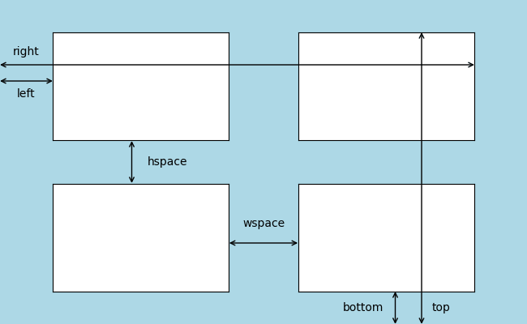

**Parameters:**

**left**float, optional**

The position of the left edge of the subplots, as a fraction of the figure width.

**right**float, optional**

The position of the right edge of the subplots, as a fraction of the figure width.

**bottom**float, optional**

The position of the bottom edge of the subplots, as a fraction of the figure height.

**top**float, optional**

The position of the top edge of the subplots, as a fraction of the figure height.

**wspace**float, optional**

The width of the padding between subplots, as a fraction of the average Axes width.

**hspace**float, optional**

The height of the padding between subplots, as a fraction of the average Axes height.

#### Notes

Note

This is the [pyplot wrapper](https://matplotlib.org/stable/users/explain/figure/api_interfaces.html#pyplot-interface) for `Figure.subplots_adjust`.

## Examples using `matplotlib.pyplot.subplots_adjust`

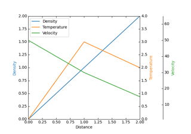

[Parasite axis demo](https://matplotlib.org/stable/gallery/axisartist/demo_parasite_axes2.html)

Parasite axis demo

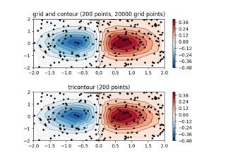

[Contour plot of irregularly spaced data](https://matplotlib.org/stable/gallery/images_contours_and_fields/irregulardatagrid.html)

Contour plot of irregularly spaced data

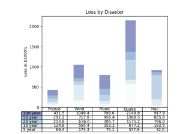

[Table Demo](https://matplotlib.org/stable/gallery/misc/table_demo.html)

Table Demo

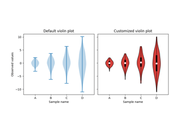

[Violin plot customization](https://matplotlib.org/stable/gallery/statistics/customized_violin.html)

Violin plot customization

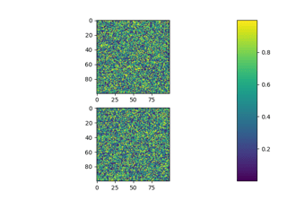

[Subplots spacings and margins](https://matplotlib.org/stable/gallery/subplots_axes_and_figures/subplots_adjust.html)

Subplots spacings and margins

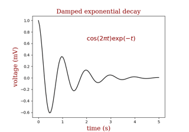

[Controlling style of text and labels using a dictionary](https://matplotlib.org/stable/gallery/text_labels_and_annotations/text_fontdict.html)

Controlling style of text and labels using a dictionary

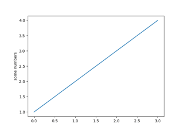

[Pyplot tutorial](https://matplotlib.org/stable/tutorials/pyplot.html)

Pyplot tutorial